## File Organization

- Project Directory
  - **`slides/`**: contains all the RMarkdown files/slides for this workshop
    - Knit `MAIN.Rmd` to see the main slideshow
    - Each section is a separate RMarkdown file
  - **`projects/`**: contains all the code we’ll be working with today
    - Each app will live in a separate directory
  - **`sandbox/`**: place to put code snippets or quick demos

## Creating a new Shiny project

How do you create a new blank Shiny app? Create a new Shiny project in `sandbox`.

Poke around RStudio and try on your own, or peer over a neighbor’s shoulder.

## Old Faithful

Using **New Project** -> **Shiny Web App** creates a living, breathing Shiny App

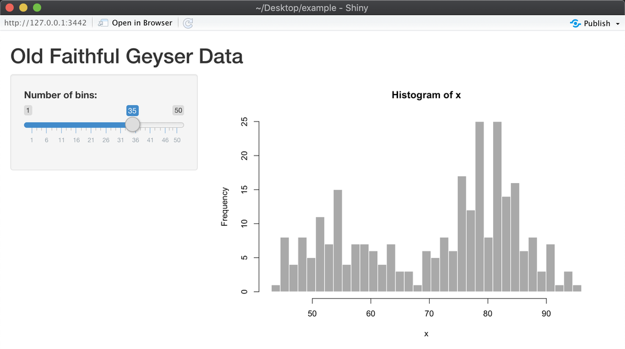

## A better way to do it

1. Open a new R Script file.
2. Start typing `shinyapp` and press **Tab** to autocomplete.
- This will expand into a “snippet” of code–the skeleton of a Shiny App.
3. Save the file in `Sandbox` and run the app.

It’s still a working Shiny app–it’s just doesn’t do anything. Starting from the snippet is less error-prone than creating a new project and deleting the guts.

Stop an app by clicking the STOP button in the console.